# DAB501: Final Project

## Group Number: 25

## Group Members:

1.AASHUTOSH SEHGAL  
2.IMAN FATIMA  
3.JASMINE  
4.RUBALDEEP KAUR  
5.UMAIR NABEEL

## Statement of Academic Integrity

We, hereby state that we have not communicated with or gained information in any way from any person or resource that would violate the College’s academic integrity policies, and that all work presented is our own. In addition, We also agree not to share my work in any way, before or after submission, that would violate the College’s academic integrity policies.

# Exploratory Data Analysis

## Univariate plots

### Sale Price

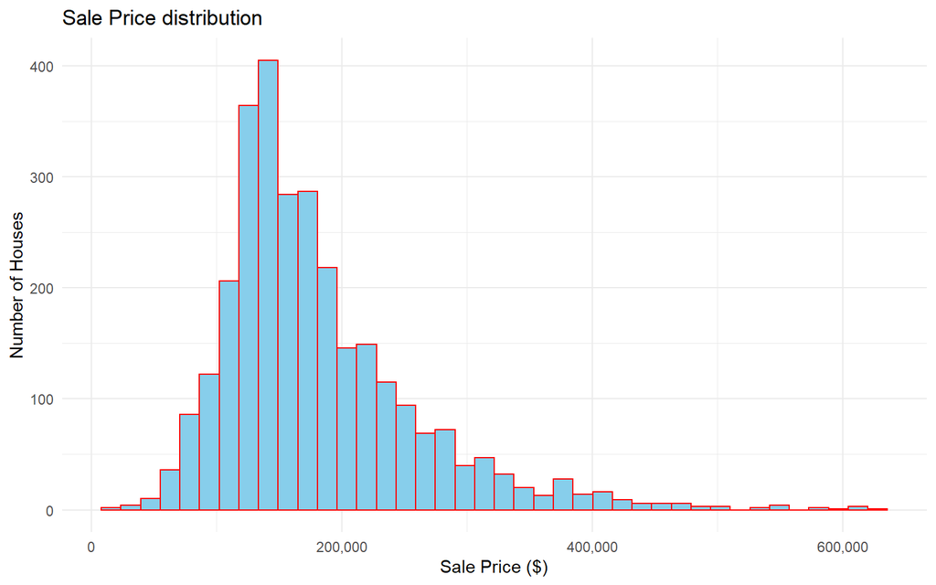

```r
ggplot(ames)+
  geom_histogram(aes(Sale_Price),bins=40,color='red',fill='skyblue')+
  theme_minimal()+
  labs(title="Sale Price distribution",x="Sale Price ($)",y="Number of Houses")+
  scale_x_continuous(labels = scales::comma)
```

```r
mean(ames$Sale_Price)
```

```
## [1] 180411.6
```

Sale Price is right-skewed; there are more inexpensive houses than expensive ones. The mean sale price is 180411.6

Checking Outliers in Sale Price using Box plot.

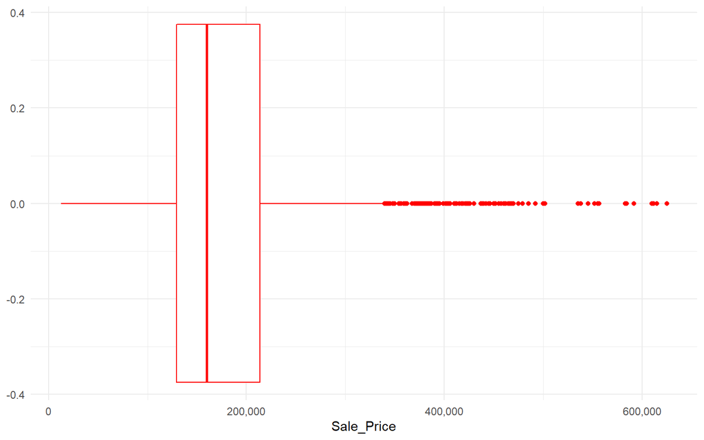

```r
ggplot(data = ames, mapping = aes(Sale_Price))+
  geom_boxplot( color = 'red')+
  scale_x_continuous(labels = scales::comma)+
  theme_minimal()
```

It is also possible to extract the values of the potential outliers based on the IQR criterion using the boxplot.stats()$out function:

```r
boxplot.stats(ames$Sale_Price)$out
```

```
##   [1] 538000 394432 376162 395192 611657 500000 355000 410000 362500 378500
##  [11] 345000 377500 375000 501837 372500 462000 485000 555000 398800 404000
##  [21] 402861 451950 610000 582933 360000 409900 350000 386250 445000 552000
##  [31] 382500 403000 340000 402000 468000 370878 375000 410000 425000 355000
##  [41] 387000 394617 426000 385000 446261 372402 417500 383000 390000 460000
##  [51] 379000 615000 412500 421250 370000 367294 370967 350000 350000 341000
##  [61] 339750 372500 345000 475000 395039 381000 392500 370000 377426 349265
##  [71] 591587 392000 441929 455000 356000 345474 415298 492000 450000 479069
##  [81] 395000 380000 440000 418000 500067 372000 342000 354000 350000 384500
##  [91] 466500 410000 430000 419005 340000 373000 383970 424870 360000 359100
## [101] 375000 392000 457347 545224 356383 556581 361919 535000 401179 438780
## [111] 470000 412083 342643 465000 415000 345000 344133 360000 372397 378000
## [121] 374000 437154 348000 625000 405000 350000 584500 423000 405749 385000
## [131] 475000 415000 375000 369900 359900
```

Extracting all the rows corresponding to these outliers:

```r
out <- boxplot.stats(ames$Sale_Price)$out
out_ind <- which(ames$Sale_Price %in% c(out))

ames[out_ind,]
```

```
## # A tibble: 135 x 74
##    MS_SubClass      MS_Zoning    Lot_Frontage Lot_Area Street Alley  Lot_Shape
##    <fct>            <fct>               <dbl>    <int> <fct>  <fct>  <fct>
##  1 Two_Story_1946_~ Residential~           47    53504 Pave   No_Al~ Moderately~
##  2 One_Story_1946_~ Residential~           88    11394 Pave   No_Al~ Regular
##  3 Two_Story_1946_~ Residential~          102    12858 Pave   No_Al~ Slightly_I~
##  4 One_Story_1946_~ Residential~           83    10159 Pave   No_Al~ Slightly_I~
##  5 One_Story_1946_~ Residential~          100    12919 Pave   No_Al~ Slightly_I~
##  6 One_Story_1946_~ Residential~          110    14300 Pave   No_Al~ Regular
##  7 Two_Story_1946_~ Residential~           60    17433 Pave   No_Al~ Moderately~
##  8 One_and_Half_St~ Residential~           56    14720 Pave   No_Al~ Slightly_I~
##  9 Two_Story_1946_~ Residential~           85    13143 Pave   No_Al~ Slightly_I~
## 10 One_Story_1946_~ Residential~           89    13214 Pave   No_Al~ Slightly_I~
## # ... with 125 more rows, and 67 more variables: Land_Contour <fct>,
## #   Utilities <fct>, Lot_Config <fct>, Land_Slope <fct>, Neighborhood <fct>,
## #   Condition_1 <fct>, Condition_2 <fct>, Bldg_Type <fct>, House_Style <fct>,
## #   Overall_Cond <fct>, Year_Built <int>, Year_Remod_Add <int>,
## #   Roof_Style <fct>, Roof_Matl <fct>, Exterior_1st <fct>, Exterior_2nd <fct>,
## #   Mas_Vnr_Type <fct>, Mas_Vnr_Area <dbl>, Exter_Cond <fct>, Foundation <fct>,
## #   Bsmt_Cond <fct>, Bsmt_Exposure <fct>, BsmtFin_Type_1 <fct>,
## #   BsmtFin_SF_1 <dbl>, BsmtFin_Type_2 <fct>, BsmtFin_SF_2 <dbl>,
## #   Bsmt_Unf_SF <dbl>, Total_Bsmt_SF <dbl>, Heating <fct>, Heating_QC <fct>,
## #   Central_Air <fct>, Electrical <fct>, First_Flr_SF <int>,
## #   Second_Flr_SF <int>, Gr_Liv_Area <int>, Bsmt_Full_Bath <dbl>,
## #   Bsmt_Half_Bath <dbl>, Full_Bath <int>, Half_Bath <int>,
## #   Bedroom_AbvGr <int>, Kitchen_AbvGr <int>, TotRms_AbvGrd <int>,
## #   Functional <fct>, Fireplaces <int>, Garage_Type <fct>, Garage_Finish <fct>,
## #   Garage_Cars <dbl>, Garage_Area <dbl>, Garage_Cond <fct>, Paved_Drive <fct>,
## #   Wood_Deck_SF <int>, Open_Porch_SF <int>, Enclosed_Porch <int>,
## #   Three_season_porch <int>, Screen_Porch <int>, Pool_Area <int>,
## #   Pool_QC <fct>, Fence <fct>, Misc_Feature <fct>, Misc_Val <int>,
## #   Mo_Sold <fct>, Year_Sold <int>, Sale_Type <fct>, Sale_Condition <fct>,
## #   Sale_Price <int>, Longitude <dbl>, Latitude <dbl>
```

### Pool Area

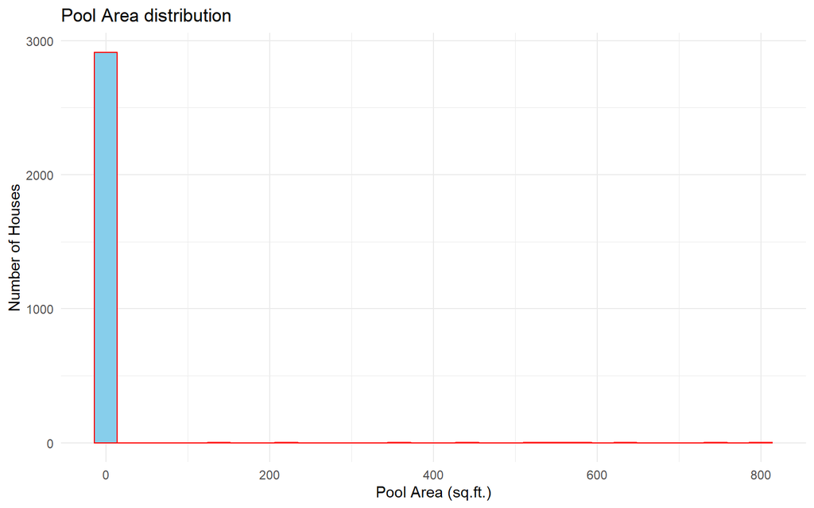

```r
ggplot(ames)+
  geom_histogram(aes(Pool_Area),color='red',fill='skyblue')+
  theme_minimal()+
  labs(title="Pool Area distribution",x="Pool Area (sq.ft.)",y="Number of Houses")
```

```r
ames %>% filter(Pool_Area>0) %>% summarize(n=n())
```

```
## # A tibble: 1 x 1
##       n
##   <int>
## 1    11
```

Pool Area is highly right skewed.Most of the houses have 0 pool area.Only 11 houses have pool area greater than zero.

### Monthly sales

```r
Monthly_sales<- ames %>%
  group_by(Mo_Sold)%>%
  summarise( n = n())%>%
  mutate(Month_sold = factor(month.abb[Mo_Sold], levels = month.abb))

Monthly_sales
```

```
## # A tibble: 12 x 3
##    Mo_Sold     n Month_sold
##    <fct>   <int> <fct>
##  1 1         121 Jan
##  2 2         133 Feb
##  3 3         232 Mar
##  4 4         279 Apr
##  5 5         395 May
##  6 6         505 Jun
##  7 7         448 Jul
##  8 8         233 Aug
##  9 9         161 Sep
## 10 10        171 Oct
## 11 11        143 Nov
## 12 12        104 Dec
```

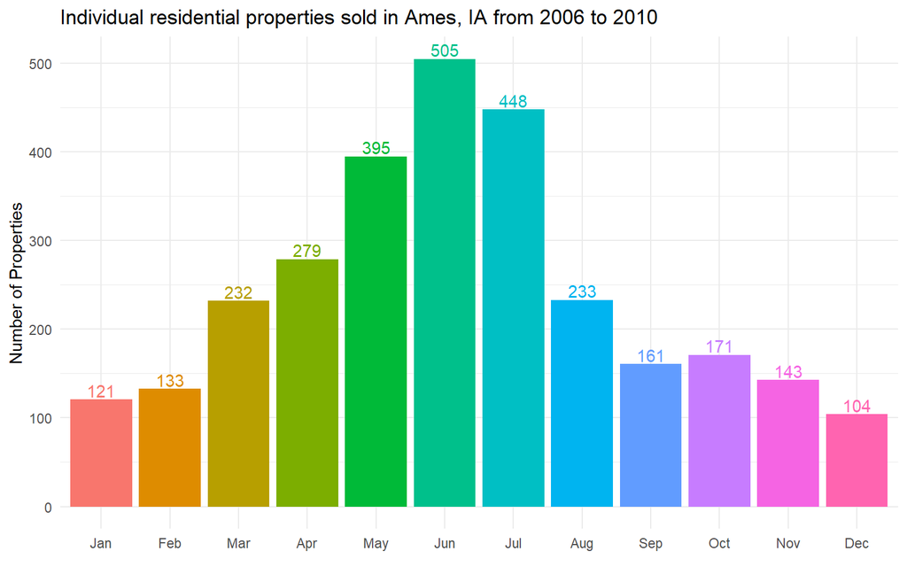

```r
ggplot(data = Monthly_sales, mapping = aes(x= Month_sold, y= n,fill = Month_sold, label = n))+
  geom_col(show.legend = FALSE)+
  geom_text(aes(label = n, color = Month_sold, vjust=-0.2),show.legend = FALSE )+
  theme_minimal()+
  labs(title = 'Individual residential properties sold in Ames, IA from 2006 to 2010')+
  xlab(element_blank())+
  ylab('Number of Properties')
```

It is clear from the plot that most of the houses were sold in the mid months i.e May, June, July and least were sold in initial and last month.

### Houses sold by Year

Let’s start. The first thing to do is to count the number of observations for each value of the year_sold. Thus, how many house are there for each year? We can do this by grouping the data on year_sold and then counting the number of rows using n.

```r
sold_house<- ames %>%
  group_by(Year_Sold)%>%
  summarise(n = n())

sold_house
```

```
## # A tibble: 5 x 2
##   Year_Sold     n
##       <int> <int>
## 1      2006   625
## 2      2007   690
## 3      2008   621
## 4      2009   648
## 5      2010   341
```

Let’s Plot it using Geom_col

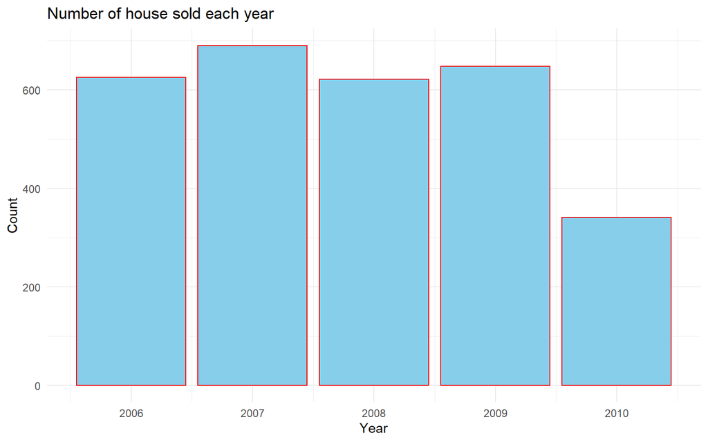

```r
ggplot(sold_house)+
  geom_col(aes(x = Year_Sold,y = n),color='red',fill='skyblue')+
  theme_minimal()+
  labs(title="Number of house sold each year",x="Year",y="Count")
```

### Lot Area

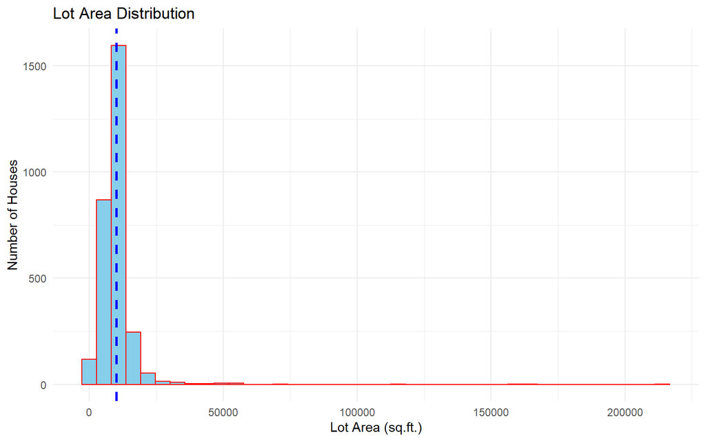

```r
ggplot(ames)+
  geom_histogram(aes(Lot_Area),bins=40,color='red',fill='skyblue')+
  geom_vline(aes(xintercept=mean(Lot_Area)),
             color="blue", linetype="dashed", size=1)+
  theme_minimal()+
  labs(title="Lot Area Distribution",x="Lot Area (sq.ft.)",y="Number of Houses")
```

```r
mean(ames$Lot_Area)
```

```
## [1] 10103.58
```

Lot Area is highly right skewed. Most of the houses have lot sizes smaller than 50000 square feet. The mean lot size is 10103.58.

### Houses Built by Year

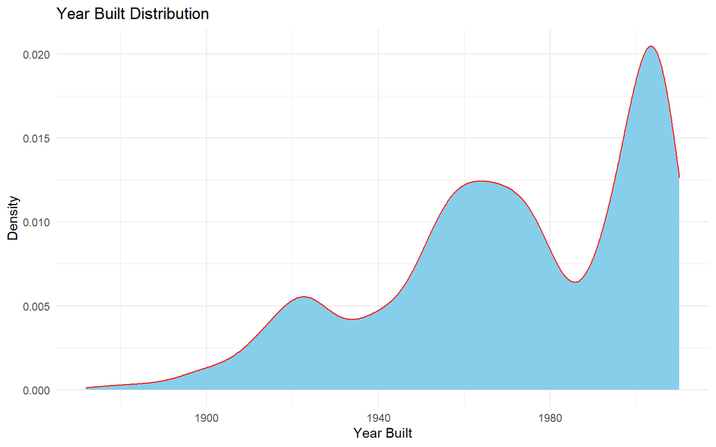

```r
ggplot(ames)+
  geom_density(aes(Year_Built),color='red',fill='skyblue')+
  theme_minimal()+
  labs(title="Year Built Distribution",x="Year Built",y="Density")
```

We have three major peaks for the years the houses are built. One around 1920, the second around 1960 and the third one after 1990

### Ground Living Area

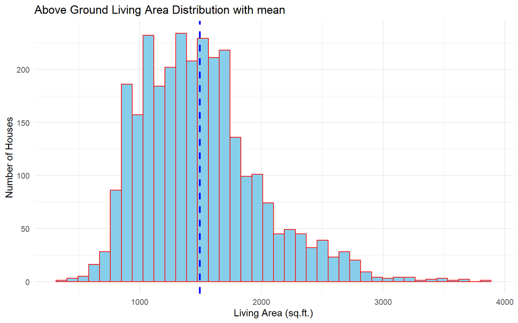

```r
ggplot(ames)+
  geom_histogram(aes(Gr_Liv_Area),bins=40,color='red',fill='skyblue')+
  geom_vline(aes(xintercept=mean(Gr_Liv_Area)),
             color="blue", linetype="dashed", size=1)+
  theme_minimal()+
  labs(title="Above Ground Living Area Distribution with mean",x="Living Area (sq.ft.)",y="Number of Houses")
```

```r
mean(ames$Gr_Liv_Area)
```

```
## [1] 1493.979
```

The distribution for Living Area is multi-nodal and right skewed. Meaning more houses have smaller living areas than larger ones. The mean is shown by the vertical line which is 1493.9

### Garage Area

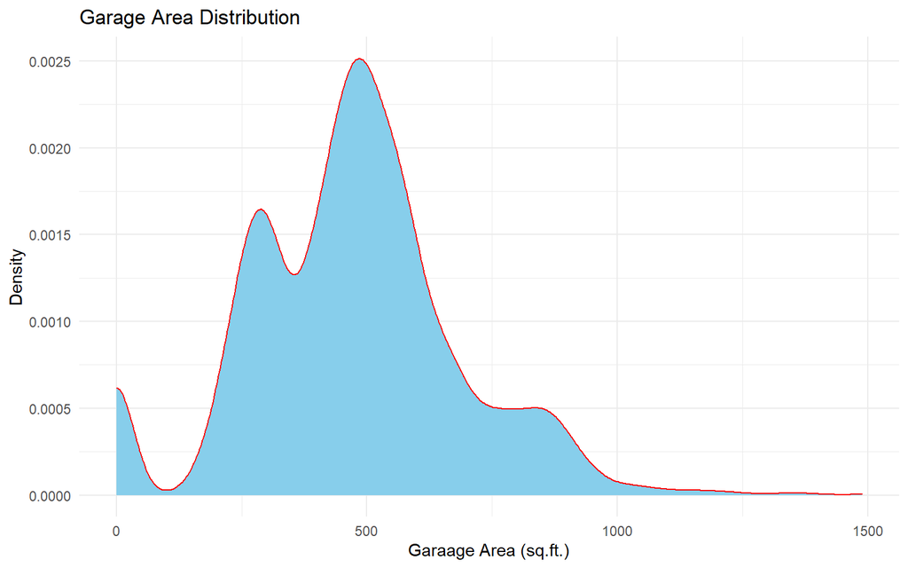

```r
ggplot(ames)+
  geom_density(aes(Garage_Area),color='red',fill='skyblue')+
  theme_minimal()+
  labs(title="Garage Area Distribution",x="Garaage Area (sq.ft.)",y="Density")
```

The distribution of Garage Area is multi-nodal and normal. Some houses have O garage area but most of the distribution is concentrated around 500 sq ft.

### Total Basement Area

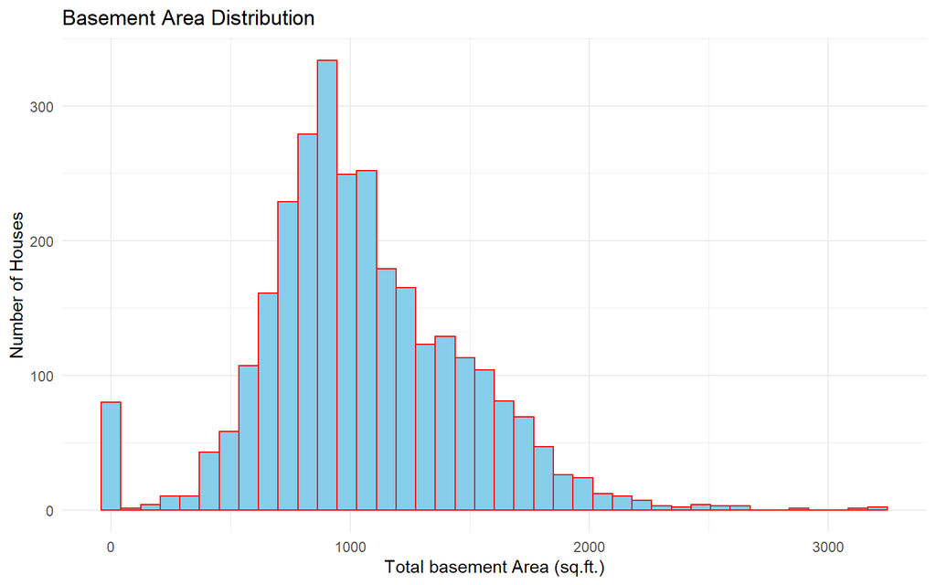

```r
ggplot(ames)+
  geom_histogram(aes(Total_Bsmt_SF),bins=40,color='red',fill='skyblue')+
  theme_minimal()+
  labs(title="Basement Area Distribution",x="Total basement Area (sq.ft.)",y="Number of Houses")
```

Total Basement Area is unimodal and slightly rightly skewed. Some houses also have no basement

### Foundation

Creating Frequency Table

```r
F_tab<- data.frame(table(ames$Foundation))
colnames(F_tab)<- c('Foundation','count')
F_tab
```

```
##   Foundation count
## 1     BrkTil   311
## 2     CBlock  1244
## 3      PConc  1305
## 4       Slab    49
## 5      Stone    11
## 6       Wood     5
```

Bar graph for foundation.

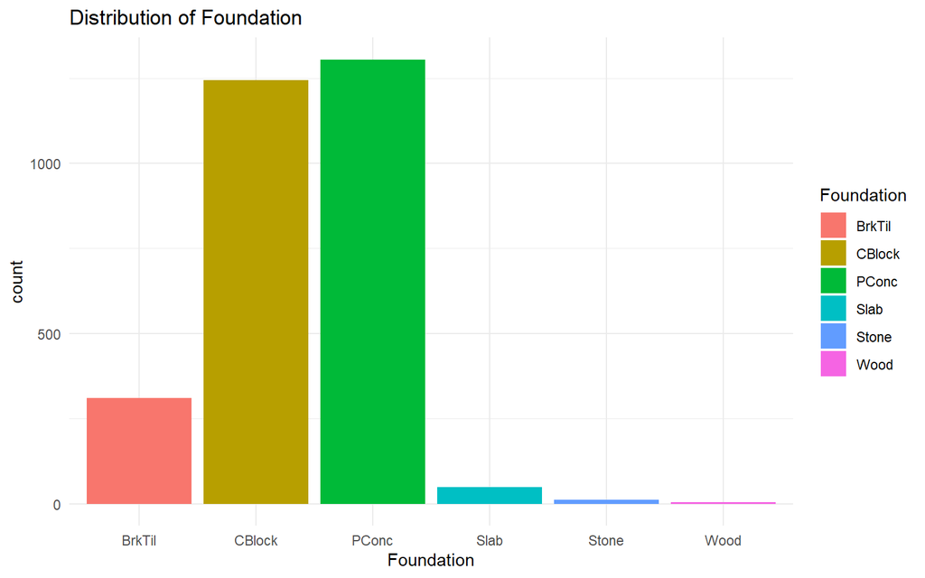

```r
ggplot(F_tab,mapping = aes(x=Foundation, y=count,fill=Foundation))+
  geom_col()+
  theme_minimal()+
  labs(title = 'Distribution of Foundation')
```

This bar chat shows that most houses were made up using CBlock and PConc and least were made using stone wood and slab.

## Bivariate plots

We will now do Bivariate analysis involving 2 variables.

### Houses sold by Year and Month

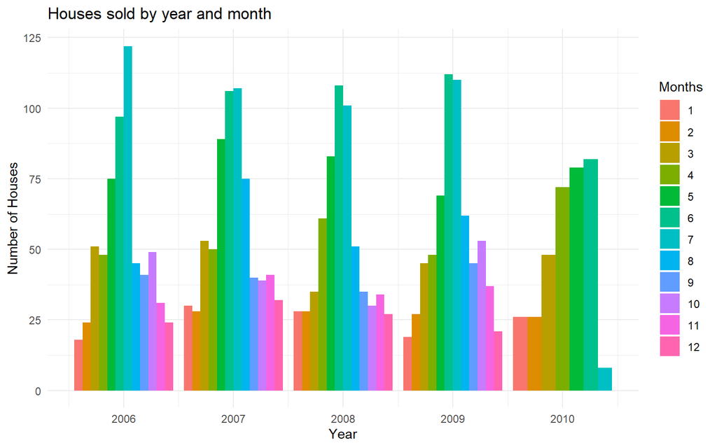

```r
ggplot(ames)+
  geom_bar(aes(Year_Sold,fill=Mo_Sold),position="dodge")+
  theme_minimal()+
  labs(title="Houses sold by year and month",x="Year",y="Number of Houses",fill="Months")
```

```r
ames %>% group_by(Year_Sold) %>% summarize(houses=n())
```

```
## # A tibble: 5 x 2
##   Year_Sold houses
##       <int>  <int>
## 1      2006    625
## 2      2007    690
## 3      2008    621
## 4      2009    648
## 5      2010    341
```

### Sale Price VS sale Year

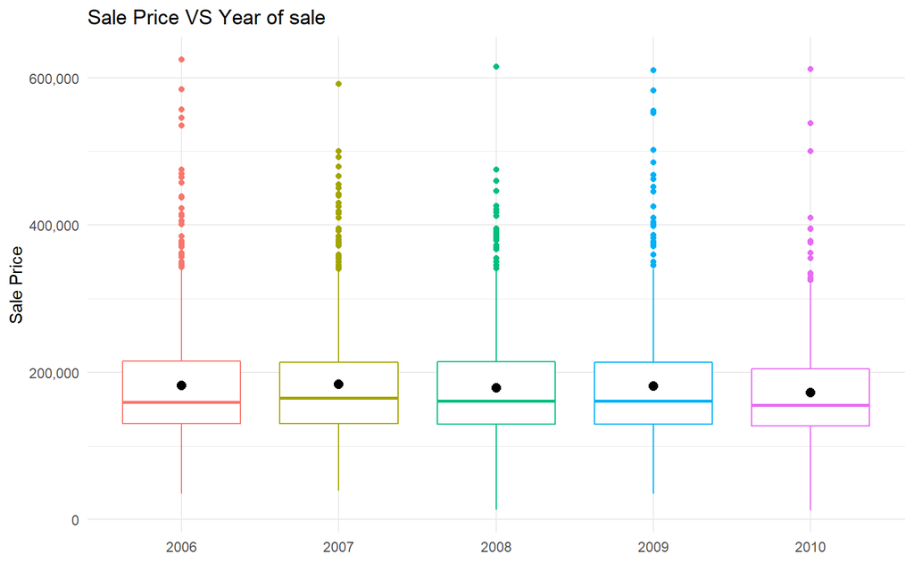

```r
ggplot(data = ames, mapping = aes(x = as.factor(Year_Sold), y = Sale_Price, color = as.factor(Year_Sold)))+
  geom_boxplot(show.legend = FALSE)+
  stat_summary(fun.y=mean, geom="point", shape=20, size=4, color="black", fill="red") +
  scale_y_continuous(labels = scales::comma)+
  theme_minimal()+
  xlab(element_blank())+
  ylab('Sale Price')+
  labs(title = 'Sale Price VS Year of sale')
```

From above plot, similar patter can be seen in all the years for sale Price. The average sale price is almost below 200,000 which represented by a black dot on the plot.

Let’s calculate it manually.

```r
mean(ames$Sale_Price)
```

```
## [1] 180411.6
```

### Sale Price VS Garage Area

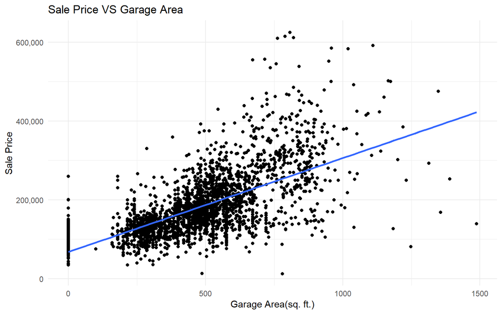

```r
ggplot(ames,aes(Garage_Area,Sale_Price))+
  geom_point()+
  geom_smooth(method='lm', se=FALSE)+
  scale_y_continuous(labels = scales::comma)+
   theme_minimal()+
  labs(title="Sale Price VS Garage Area",x="Garage Area(sq. ft.)",y="Sale Price")
```

```r
cor(ames$Garage_Area,ames$Sale_Price)
```

```
## [1] 0.6480499
```

A strong positive correlation exists for garage area and sale price. It means as Garage Area increases, Sale Price also increases.

### Neighborhood VS Sale Price

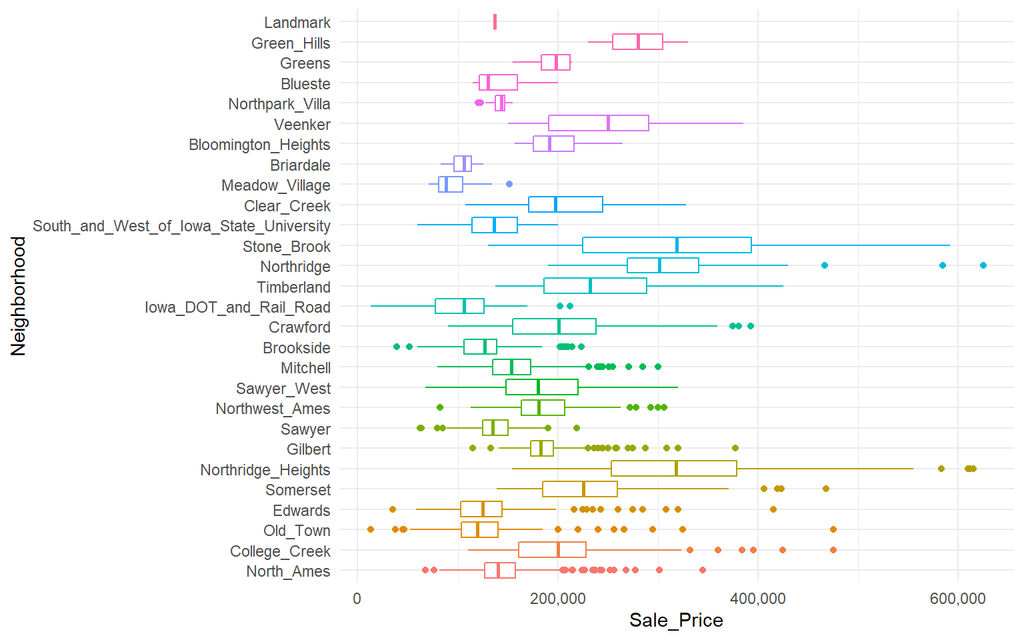

```r
ggplot(ames,mapping = aes(x = Neighborhood,y = Sale_Price ))+
  geom_boxplot(aes(color = Neighborhood), show.legend=FALSE)+
  scale_y_continuous(labels = scales::comma)+
  theme_minimal()+
  coord_flip()
```

It is seen that Northridge Heights and Stony Brook are the most expensive neighborhoods. Northridge Heights has a great significance on the sale price of the houses.

### Houses by Neighborhood and Lot type

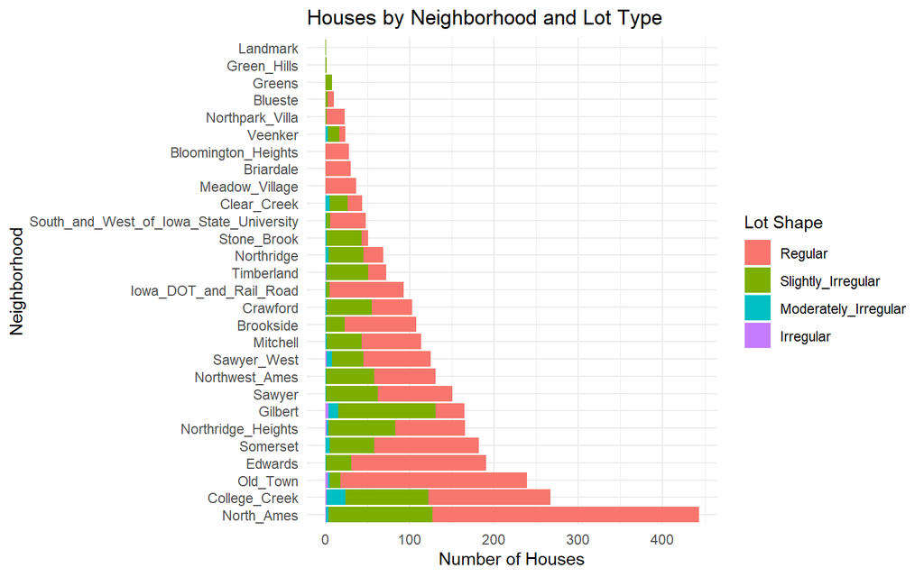

```r
ggplot(ames)+
  geom_bar(aes(Neighborhood,fill=Lot_Shape))+
  theme_minimal()+
  labs(title="Houses by Neighborhood and Lot Type",x="Neighborhood",y="Number of Houses",fill="Lot Shape")+
  coord_flip()
```

North Ames Neighborhood has the highest number of houses with Regular Lot Type

### Sale Price VS Total Basement Area

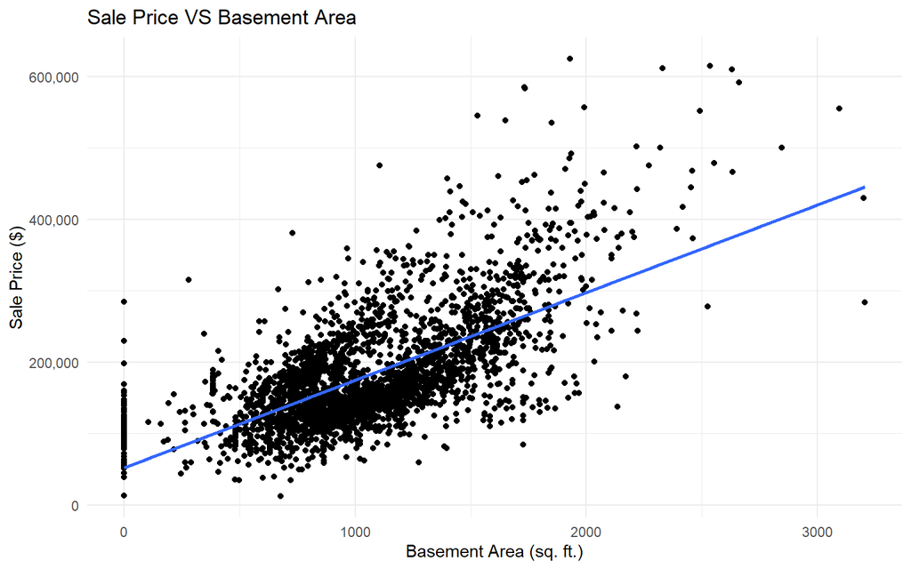

```r
ggplot(ames,aes(Total_Bsmt_SF,Sale_Price))+
  geom_point()+
  geom_smooth(method='lm', se=FALSE)+
  scale_y_continuous(labels = scales::comma)+
   theme_minimal()+
  labs(title="Sale Price VS Basement Area",x="Basement Area (sq. ft.)",y="Sale Price ($)")
```

```r
cor(ames$Total_Bsmt_SF,ames$Sale_Price)
```

```
## [1] 0.6588634
```

A strong positive correlation exists between Basement area and sale price. It means as Basement Area of houses increases, their sale Price also increases.

### Sale Price VS Year Built

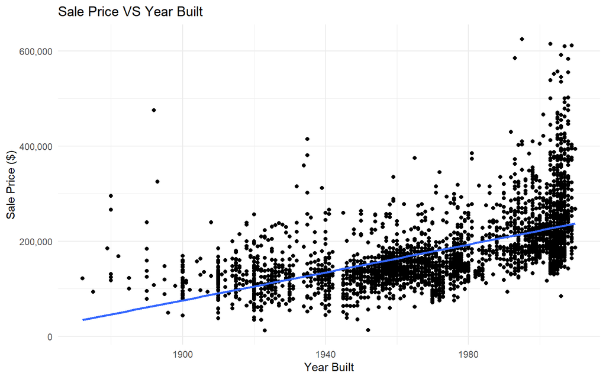

```r
ggplot(ames,aes(Year_Built,Sale_Price))+
  geom_point()+
  geom_smooth(method='lm', se=FALSE)+
  scale_y_continuous(labels = scales::comma)+
  theme_minimal()+
  labs(title="Sale Price VS Year Built",x="Year Built",y="Sale Price ($)")
```

```r
cor(ames$Year_Built,ames$Sale_Price)
```

```
## [1] 0.5651105
```

A strong positive correlation exists between Year built and Sale price. It means that newer houses are sold at higher prices and houses built in the earlier years were sold for lesser prices.

### Sale Price VS Lot Area

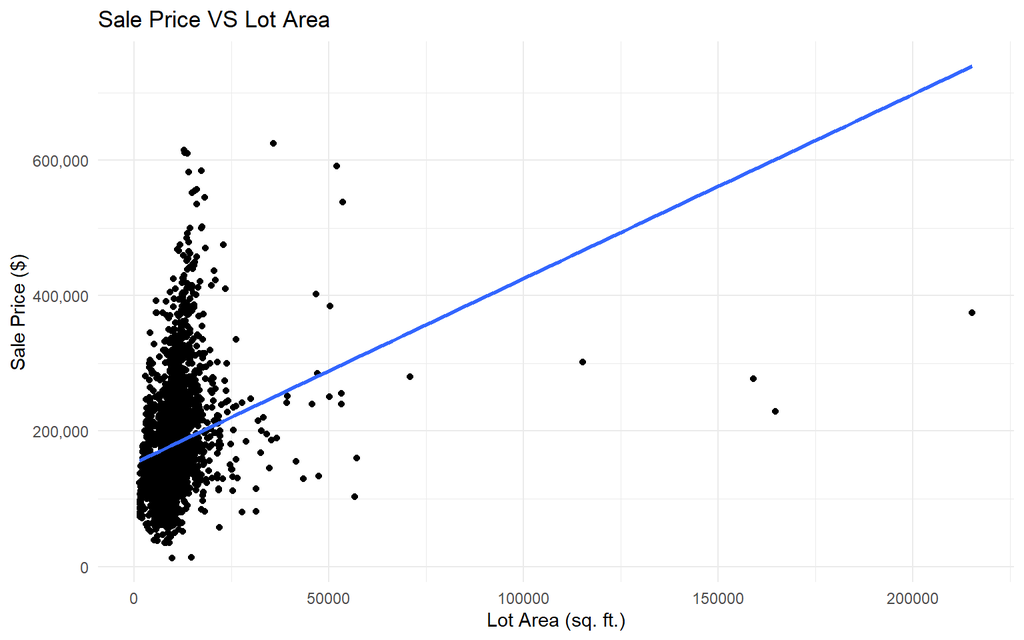

```r
ggplot(ames,aes(Lot_Area,Sale_Price))+
  geom_point()+
  geom_smooth(method='lm', se=FALSE)+
  scale_y_continuous(labels = scales::comma)+
    theme_minimal()+
  labs(title="Sale Price VS Lot Area",x="Lot Area (sq. ft.)",y="Sale Price ($)")
```

```r
 cor(ames$Lot_Area,ames$Sale_Price)
```

```
## [1] 0.2700472
```

## Multivariate plots

We will now do Multivariate analysis involving more than 2 variables.

### Relationship between Sale Price and Year Built based on Street type

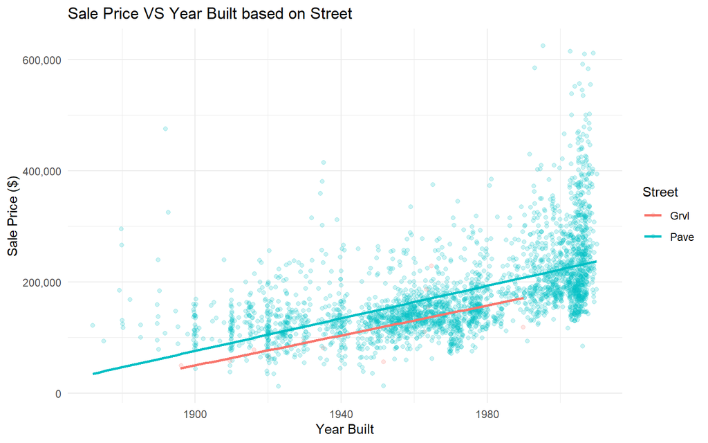

```r
ggplot(ames,aes(Year_Built,Sale_Price,color = Street))+
  geom_jitter(alpha = 0.2)+
  geom_smooth(method='lm', se=FALSE)+
  scale_y_continuous(labels = scales::comma)+
  theme_minimal()+
  labs(title="Sale Price VS Year Built based on Street",x="Year Built",y="Sale Price ($)")
```

The above scatter plot shows a linear and direct relationship between built year and sale price for both type of streets.Almost all houses were connected with Paved streets and only few were with gravel streets.

### Relationship between Sale price and sold year based on Paved Driveway

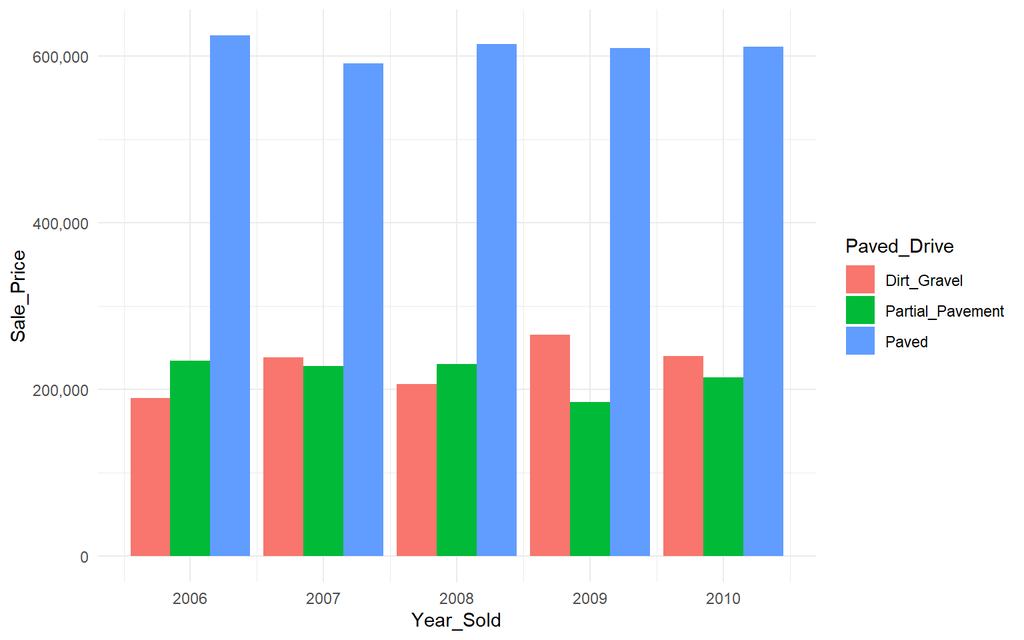

```r
ggplot(data = ames,mapping = aes(Year_Sold,Sale_Price,fill = Paved_Drive) )+
  geom_bar(stat = 'identity',position='dodge')+
  scale_y_continuous(labels = scales::comma)+
  theme_minimal()
```

Mostly expensive houses had paved driveway for all the given years in which they were sold. Houses with price range around $200,000 were connected to partial pavement and Dirt Gravel, similar price pattern can be seen for all properties for all years.

```r
unique(ames$Sale_Type)
```

```
##  [1] WD    New   COD   ConLI Con   ConLD Oth   ConLw CWD   VWD
## Levels: COD Con ConLD ConLI ConLw CWD New Oth VWD WD
```

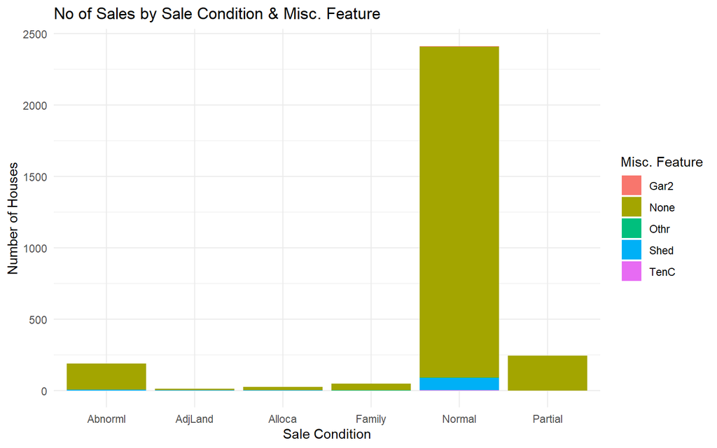

[figure not shown]

[figure not shown]

## Summary

```r
#ames %>%
#  group_by() %>%
#  summarize(mean_ = mean())
```

Quick Description

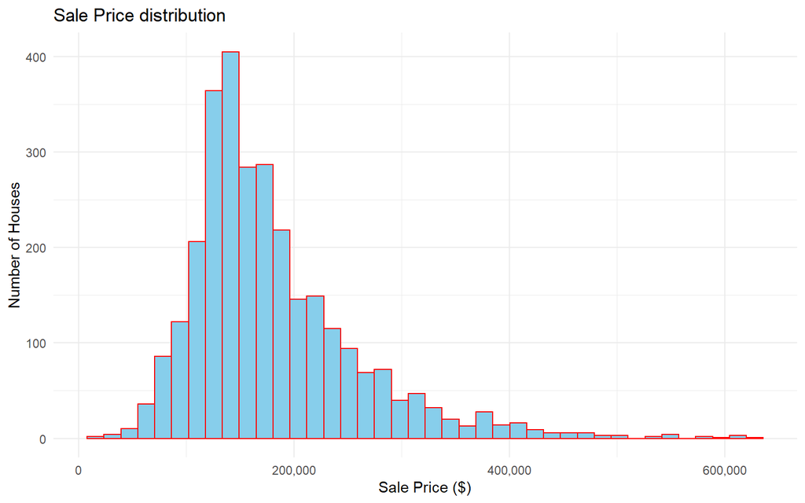

# Modeling

## Model 1 (Sale Price ~ Lot Area)

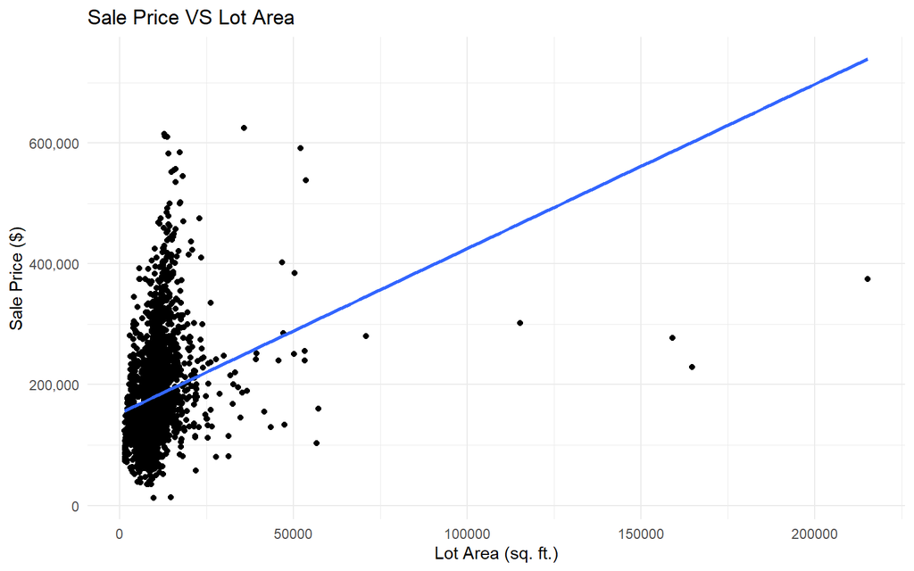

```r
ggplot(ames,aes(Lot_Area,Sale_Price))+
  geom_point()+
  geom_smooth(method='lm', se=FALSE)+
  scale_y_continuous(labels = scales::comma)+
    theme_minimal()+
  labs(title="Sale Price VS Lot Area",x="Lot Area (sq. ft.)",y="Sale Price ($)")
```

```r
ames %>%
  summarise(cor(Lot_Area, Sale_Price))
```

```
## # A tibble: 1 x 1
##   `cor(Lot_Area, Sale_Price)`
##                         <dbl>
## 1                       0.270
```

```r
m1 <- lm(Sale_Price ~ Lot_Area, data = ames)
tidy(m1)
```

```
## # A tibble: 2 x 5
##   term         estimate std.error statistic  p.value
##   <chr>           <dbl>     <dbl>     <dbl>    <dbl>
## 1 (Intercept) 152869.    2293.         66.7 0
## 2 Lot_Area         2.73     0.180      15.2 4.72e-50
```

$$\hat{y} = 152869.484 + 2.73 \times Lot-Area$$

This equation tells us two things:

- For houses with a `Lot_Area` of 0 we expect their mean sale price to be 152869.484 dollars.
- For every 1 square ft increase in `Lot_Area`, we expect an sale price to increase on an average of 2.73 dollars.

```r
glance(m1)
```

```
## # A tibble: 1 x 12
##   r.squared adj.r.squared  sigma statistic  p.value    df  logLik    AIC    BIC
##       <dbl>         <dbl>  <dbl>     <dbl>    <dbl> <dbl>   <dbl>  <dbl>  <dbl>
## 1    0.0729        0.0726 75649.      230. 4.72e-50     1 -37008. 74023. 74041.
## # ... with 3 more variables: deviance <dbl>, df.residual <int>, nobs <int>
```

For this model, 7.29% of the variability in `Sale_Price` is explained by `Lot_Area`.

## Model 2 (Sale Price ~ Garage Area)

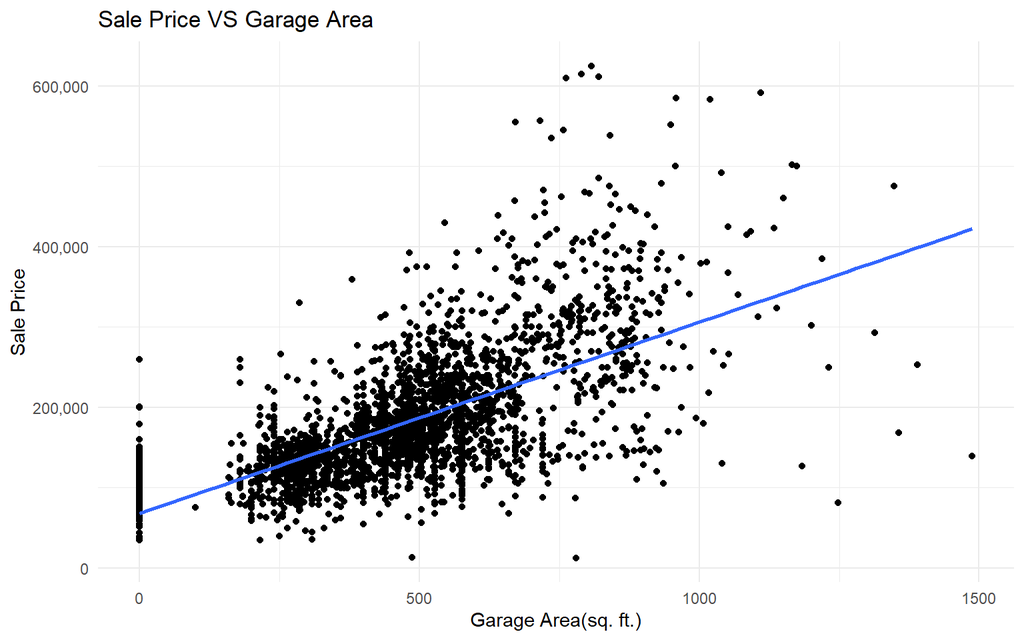

```r
ggplot(ames,aes(Garage_Area,Sale_Price))+
  geom_point()+
  geom_smooth(method='lm', se=FALSE)+
  scale_y_continuous(labels = scales::comma)+
   theme_minimal()+
  labs(title="Sale Price VS Garage Area",x="Garage Area(sq. ft.)",y="Sale Price")
```

```r
ames %>%
  summarise(cor(Garage_Area, Sale_Price))
```

```
## # A tibble: 1 x 1
##   `cor(Garage_Area, Sale_Price)`
##                            <dbl>
## 1                          0.648
```

```r
m2 <- lm(Sale_Price ~ Garage_Area, data = ames)
tidy(m2)
```

```
## # A tibble: 2 x 5
##   term        estimate std.error statistic   p.value
##   <chr>          <dbl>     <dbl>     <dbl>     <dbl>
## 1 (Intercept)   68173.   2679.        25.4 3.26e-129
## 2 Garage_Area     238.      5.17      46.0 0
```

$$\hat{y} = 68173.409 + 238 \times Garage-Area$$
This equation tells us two things:

- For houses with a `Garage_Area` of 0 we expect their mean sale price to be 68173.409 dollars.
- For every 1 square ft increase in `Garage_Area`, we expect an increase of mean sale price to increase 238 dollars.

```r
glance(m2)
```

```
## # A tibble: 1 x 12
##   r.squared adj.r.squared  sigma statistic p.value    df  logLik    AIC    BIC
##       <dbl>         <dbl>  <dbl>     <dbl>   <dbl> <dbl>   <dbl>  <dbl>  <dbl>
## 1     0.420         0.420 59837.     2116.       0     1 -36323. 72651. 72669.
## # ... with 3 more variables: deviance <dbl>, df.residual <int>, nobs <int>
```

For this model, 42.0% of the variability in `Sale_Price` is explained by `Garage_Area`.

## Model 3 (Sale Price ~ Living Area)

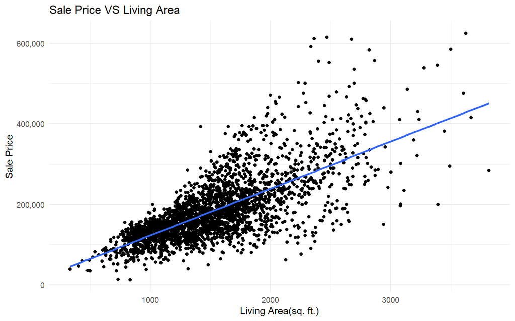

```r
# some code goes here
ggplot(ames,aes(Gr_Liv_Area,Sale_Price))+
  geom_point() +
  geom_smooth(method = 'lm',se=FALSE)+
   scale_y_continuous(labels = scales::comma)+
   theme_minimal()+
  labs(title="Sale Price VS Living Area",x="Living Area(sq. ft.)",y="Sale Price")
```

```r
ames %>%
  summarise(cor(Gr_Liv_Area, Sale_Price))
```

```
## # A tibble: 1 x 1
##   `cor(Gr_Liv_Area, Sale_Price)`
##                            <dbl>
## 1                          0.719
```

```r
m3 <- lm(Sale_Price ~ Gr_Liv_Area, data = ames)
tidy(m3)
```

```
## # A tibble: 2 x 5
##   term        estimate std.error statistic p.value
##   <chr>          <dbl>     <dbl>     <dbl>   <dbl>
## 1 (Intercept)    6773.   3260.        2.08  0.0378
## 2 Gr_Liv_Area     116.      2.08     56.0   0
```

$$\hat{y} = 6773.484 + 116.2 \times Gr-Liv-Area$$

This equation tells us two things:

- For houses with a `Gr_Liv_Area` of 0 we expect their mean sale price to be 6773.484 dollars.
- For every 1 square ft increase in `Gr_Liv_Area`, we expect an sale price to increase on an average 116.2 dollars.

```r
glance(m3)
```

```
## # A tibble: 1 x 12
##   r.squared adj.r.squared  sigma statistic p.value    df  logLik    AIC    BIC
##       <dbl>         <dbl>  <dbl>     <dbl>   <dbl> <dbl>   <dbl>  <dbl>  <dbl>
## 1     0.518         0.517 54568.     3137.       0     1 -36053. 72112. 72130.
## # ... with 3 more variables: deviance <dbl>, df.residual <int>, nobs <int>
```

For this model, 51.8% of the variability in `Sale_Price` is explained by `Gr_Liv_Area`.

## Model Assessment

```r
library(modelsummary)

models <- list(
  "Sale Price ~ Lot_Area"     = m1,
 "Sale Price ~ Garage_Area" = m2,
  "Sale Price ~ Gr_Liv_Area"=m3
)

modelsummary(models)
```

|  | Sale Price ~ Lot_Area | Sale Price ~ Garage_Area | Sale Price ~ Gr_Liv_Area |
| --- | --- | --- | --- |
| (Intercept) | 152869.484 | 68173.409 | 6773.484 |
|  | (2292.521) | (2678.887) | (3260.418) |
| Lot_Area | 2.726 |  |  |
|  | (0.180) |  |  |
| Garage_Area |  | 237.933 |  |
|  |  | (5.172) |  |
| Gr_Liv_Area |  |  | 116.225 |
|  |  |  | (2.075) |
| Num.Obs. | 2925 | 2925 | 2925 |
| R2 | 0.073 | 0.420 | 0.518 |
| R2 Adj. | 0.073 | 0.420 | 0.517 |
| AIC | 74022.9 | 72651.2 | 72111.9 |
| BIC | 74040.8 | 72669.1 | 72129.9 |
| Log.Lik. | -37008.444 | -36322.602 | -36052.970 |
| F | 229.929 | 2116.383 | 3136.620 |

Out of all three models, Model 1 has the least R2 of about 7.3% which means higher variability around the regression line.

## Model Diagnostics

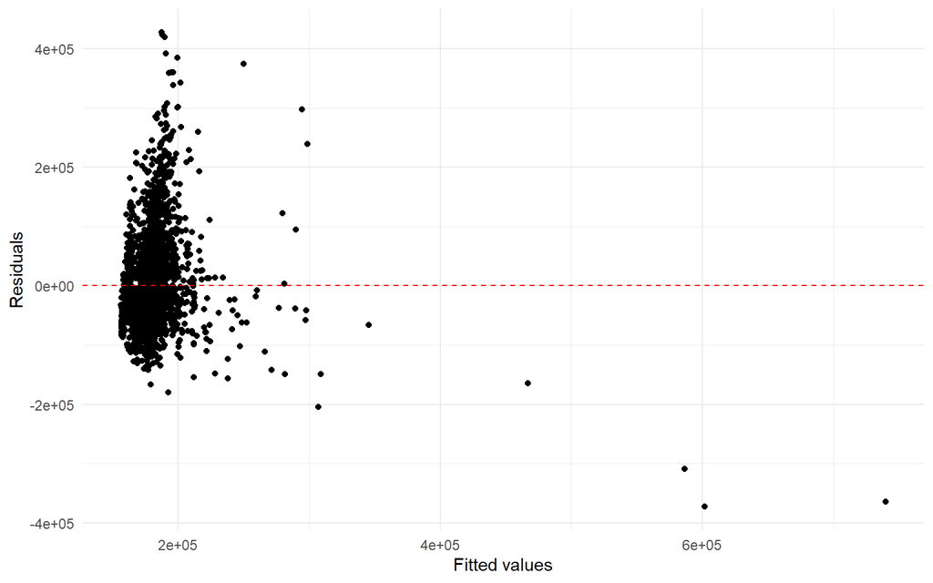

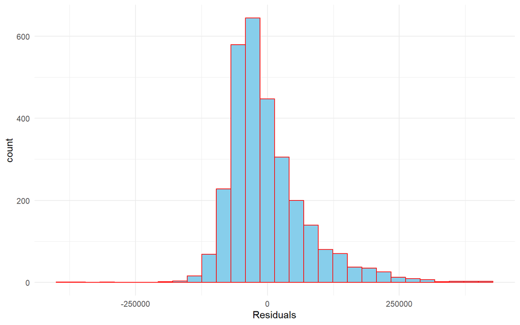

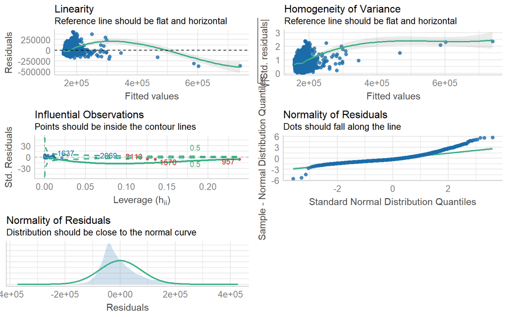

[figure not shown]